# Statistical Learning Project

Homework 1: Unsupervised Learning

2024-11-08

# Libraries

```r
library(dplyr)
library(GGally)
```

```r
library(ggplot2)
library(factoextra)
library(cluster)
library(mclust)
library(kernlab)
library(MASS)
```

# Dataset and variable selection

We have decided to use the R-library NHANES(National Health and Nutrition Examination Survey) dataset for our project. It is a dataset that shows the health data of survey takers in the year intervals 2009-2010 and 2011-2012. This dataset has 10000 observations and 76 variables.

```r
install.packages("NHANES")
library(NHANES)
```

If the previous code doesn’t work due to different version of RStudio, the following code should work. Please set your working directory to be the folder with all the documents of our homework.

```r
NHANES <- read.csv("NHANES_data.csv")
```

```r
data("NHANES")
head(NHANES)
```

```
## # A tibble: 6 × 76
##      ID SurveyYr Gender   Age AgeDecade AgeMonths Race1 Race3 Education
##   <int> <fct>    <fct>  <int> <fct>         <int> <fct> <fct> <fct>
## 1 51624 2009_10  male      34 " 30-39"        409 White <NA>  High School
## 2 51624 2009_10  male      34 " 30-39"        409 White <NA>  High School
## 3 51624 2009_10  male      34 " 30-39"        409 White <NA>  High School
## 4 51625 2009_10  male       4 " 0-9"           49 Other <NA>  <NA>
## 5 51630 2009_10  female    49 " 40-49"        596 White <NA>  Some College
## 6 51638 2009_10  male       9 " 0-9"          115 White <NA>  <NA>
## # ℹ 67 more variables: MaritalStatus <fct>, HHIncome <fct>, HHIncomeMid <int>,
## #   Poverty <dbl>, HomeRooms <int>, HomeOwn <fct>, Work <fct>, Weight <dbl>,
## #   Length <dbl>, HeadCirc <dbl>, Height <dbl>, BMI <dbl>,
## #   BMICatUnder20yrs <fct>, BMI_WHO <fct>, Pulse <int>, BPSysAve <int>,
## #   BPDiaAve <int>, BPSys1 <int>, BPDia1 <int>, BPSys2 <int>, BPDia2 <int>,
## #   BPSys3 <int>, BPDia3 <int>, Testosterone <dbl>, DirectChol <dbl>,
## #   TotChol <dbl>, UrineVol1 <int>, UrineFlow1 <dbl>, UrineVol2 <int>, …
```

Looking at the first three observations’ ID, we see that there are some repetitions. Our first step will be to remove those repetitions. Then looking at the summary of the data, we can see that there are columns that have a lot of NA values and variables that are factors. For our purposes of using this data for unsupervised learning, we can remove those variables.

```r
# choose only the unique observations
unique_data <- NHANES %>% distinct(ID, .keep_all = TRUE)
summary(unique_data)
```

```
##        ID           SurveyYr       Gender          Age          AgeDecade
##  Min.   :51624   2009_10:3568   female:3420   Min.   : 0.00    0-9   :1109
##  1st Qu.:56568   2011_12:3211   male  :3359   1st Qu.:15.00    10-19 :1016
##  Median :61615                                Median :34.00    30-39 : 895
##  Mean   :61657                                Mean   :35.45    20-29 : 880
##  3rd Qu.:66778                                3rd Qu.:54.00    40-49 : 845
##  Max.   :71915                                Max.   :80.00   (Other):1785
##                                                               NA's   : 249
##    AgeMonths          Race1           Race3               Education
##  Min.   :  0.0   Black   :1024   Asian   : 252   8th Grade     : 359
##  1st Qu.:170.0   Hispanic: 495   Black   : 514   9 - 11th Grade: 624
##  Median :388.0   Mexican : 859   Hispanic: 274   High School   : 993
##  Mean   :404.4   White   :3783   Mexican : 390   Some College  :1423
##  3rd Qu.:616.0   Other   : 618   White   :1667   College Grad  :1246
##  Max.   :959.0                   Other   : 114   NA's          :2134
##  NA's   :3230                    NA's    :3568
##       MaritalStatus         HHIncome     HHIncomeMid        Poverty
##  Divorced    : 443   more 99999 :1303   Min.   :  2500   Min.   :0.000
##  LivePartner : 374   75000-99999: 691   1st Qu.: 22500   1st Qu.:1.090
##  Married     :2463   25000-34999: 689   Median : 50000   Median :2.310
##  NeverMarried: 899   35000-44999: 608   Mean   : 53786   Mean   :2.607
##  Separated   : 135   45000-54999: 511   3rd Qu.: 87500   3rd Qu.:4.340
##  Widowed     : 336   (Other)    :2392   Max.   :100000   Max.   :5.000
##  NA's        :2129   NA's       : 585   NA's   :585      NA's   :518
##    HomeRooms       HomeOwn             Work          Weight
##  Min.   : 1.000   Own  :4149   Looking   : 210   Min.   :  2.80
##  1st Qu.: 5.000   Rent :2419   NotWorking:1984   1st Qu.: 53.40
##  Median : 6.000   Other: 167   Working   :2852   Median : 71.10
##  Mean   : 6.139   NA's :  44   NA's      :1733   Mean   : 69.06
##  3rd Qu.: 7.000                                  3rd Qu.: 87.60
##  Max.   :13.000                                  Max.   :230.70
##  NA's   :48                                      NA's   :55
##      Length          HeadCirc         Height           BMI
##  Min.   : 47.10   Min.   :34.20   Min.   : 83.6   Min.   :12.88
##  1st Qu.: 74.33   1st Qu.:39.50   1st Qu.:155.4   1st Qu.:21.23
##  Median : 86.65   Median :41.30   Median :165.1   Median :25.80
##  Mean   : 84.59   Mean   :41.09   Mean   :160.4   Mean   :26.49
##  3rd Qu.: 95.60   3rd Qu.:43.00   3rd Qu.:173.7   3rd Qu.:30.60
##  Max.   :112.20   Max.   :45.40   Max.   :200.4   Max.   :81.25
##  NA's   :6317     NA's   :6702    NA's   :298     NA's   :304
```

[output cut: 89 more lines]

```
##  No  : 157   Min.   : 9.00   Min.   :   0.00   Min.   : 0.000   No  :3357
##  Yes :3458   1st Qu.:15.00   1st Qu.:   2.00   1st Qu.: 1.000   Yes : 258
##  NA's:3164   Median :17.00   Median :   5.00   Median : 1.000   NA's:3164
##              Mean   :17.41   Mean   :  14.74   Mean   : 1.344
##              3rd Qu.:19.00   3rd Qu.:  12.00   3rd Qu.: 1.000
##              Max.   :50.00   Max.   :2000.00   Max.   :69.000
##              NA's   :3325    NA's   :3192      NA's   :3705
##       SexOrientation  PregnantNow
##  Bisexual    :  80   Yes    :  49
##  Heterosexual:2876   No     :1037
##  Homosexual  :  53   Unknown:  33
##  NA's        :3770   NA's   :5660
##
##
##
```

```r
# Choose which variables will be most useful
my_data = unique_data %>% dplyr::select("Gender", "Age", "HHIncomeMid", "Weight", "Height", "BMI",
                                 "Pulse", "BPSysAve", "BPDiaAve", "TotChol",
                                 "UrineVol1", "UrineFlow1", "DaysPhysHlthBad",
                                 "DaysMentHlthBad", "SleepHrsNight", "PhysActiveDays",
                                 "SexAge")
```

# Dealing with NA values

```r
# Find which rows have the most NA values
na_count <- rowSums(is.na(my_data))
unique_na_counts <- unique(na_count)
unique_na_counts # there are rows with missing from 0 - 14
```

```
##  [1]  2 11  1  5  0  7  3  6  4 13  9  8 14 12 10
```

```r
# As some rows have a lot of missing data, it would be best if we remove them.
# Hence any rows that have more than 6 missing values will be removed
new_data <- my_data[!(na_count %in% c(6, 7, 8, 9, 10, 11, 12, 13, 14)), ]
# We are left with 5559 observations, which is good.
summary(new_data)
```

```
##     Gender          Age         HHIncomeMid         Weight
##  female:2808   Min.   : 8.00   Min.   :  2500   Min.   : 21.70
##  male  :2751   1st Qu.:23.00   1st Qu.: 22500   1st Qu.: 62.40
##                Median :40.00   Median : 50000   Median : 76.00
##                Mean   :41.07   Mean   : 54602   Mean   : 77.88
##                3rd Qu.:57.00   3rd Qu.: 87500   3rd Qu.: 90.65
##                Max.   :80.00   Max.   :100000   Max.   :230.70
##                                NA's   :449      NA's   :28
##      Height           BMI            Pulse           BPSysAve
##  Min.   :119.1   Min.   :12.90   Min.   : 40.00   Min.   : 76.0
##  1st Qu.:159.4   1st Qu.:22.88   1st Qu.: 64.00   1st Qu.:106.0
##  Median :167.1   Median :26.77   Median : 72.00   Median :116.0
##  Mean   :166.7   Mean   :27.76   Mean   : 73.44   Mean   :118.4
##  3rd Qu.:175.0   3rd Qu.:31.50   3rd Qu.: 82.00   3rd Qu.:127.0
##  Max.   :200.4   Max.   :81.25   Max.   :136.00   Max.   :226.0
##  NA's   :27      NA's   :32      NA's   :76       NA's   :84
##     BPDiaAve         TotChol         UrineVol1       UrineFlow1
##  Min.   :  0.00   Min.   : 1.530   Min.   :  0.0   Min.   : 0.0000
##  1st Qu.: 60.00   1st Qu.: 4.110   1st Qu.: 50.0   1st Qu.: 0.4040
##  Median : 68.00   Median : 4.780   Median : 94.0   Median : 0.6920
##  Mean   : 67.05   Mean   : 4.872   Mean   :119.2   Mean   : 0.9662
##  3rd Qu.: 76.00   3rd Qu.: 5.530   3rd Qu.:165.0   3rd Qu.: 1.2140
##  Max.   :116.00   Max.   :13.650   Max.   :510.0   Max.   :12.3460
##  NA's   :84       NA's   :306      NA's   :38      NA's   :346
##  DaysPhysHlthBad  DaysMentHlthBad  SleepHrsNight    PhysActiveDays
##  Min.   : 0.000   Min.   : 0.000   Min.   : 2.000   Min.   :1.000
##  1st Qu.: 0.000   1st Qu.: 0.000   1st Qu.: 6.000   1st Qu.:2.000
##  Median : 0.000   Median : 0.000   Median : 7.000   Median :3.000
##  Mean   : 3.497   Mean   : 4.114   Mean   : 6.916   Mean   :3.736
##  3rd Qu.: 3.000   3rd Qu.: 4.000   3rd Qu.: 8.000   3rd Qu.:5.000
##  Max.   :30.000   Max.   :30.000   Max.   :12.000   Max.   :7.000
##  NA's   :692      NA's   :692      NA's   :699      NA's   :2790
##      SexAge
##  Min.   : 9.00
##  1st Qu.:15.00
##  Median :17.00
##  Mean   :17.41
##  3rd Qu.:19.00
##  Max.   :50.00
##  NA's   :2112
```

```r
# With the summary we can see that every column has a lot of missing values,
# but PhysActiveDays and SexAge have the most(>2100), so it would be better
# to remove those columns.
new_data = new_data %>% dplyr::select(-PhysActiveDays, -SexAge)
```

For the rest of the variables we will replace the NA values with the average of each variable.

```r
# As BMI is calculated based on weight and height, we can replace the the NA
# values in that column by calculating it.
new_data$Weight[is.na(new_data$Weight)] <- mean(new_data$Weight, na.rm = TRUE)
new_data$Height[is.na(new_data$Height)] <- mean(new_data$Height, na.rm = TRUE)
new_data$BMI[is.na(new_data$BMI)] <- new_data$Weight[is.na(new_data$BMI)] / (new_data$Height[is.na(new_data$BMI)]^2)
new_data <- new_data %>%
  mutate(across(where(is.numeric), ~ ifelse(is.na(.), mean(., na.rm = TRUE), .)))
```

As that function will make all of the integer values into numerical, we will transform them back to integers.

```r
new_data$Pulse = as.integer(new_data$Pulse)
new_data$BPSysAve = as.integer(new_data$BPSysAve)
new_data$BPDiaAve = as.integer(new_data$BPDiaAve)
new_data$UrineVol1 = as.integer(new_data$UrineVol1)
new_data$DaysPhysHlthBad = as.integer(new_data$DaysPhysHlthBad)
new_data$DaysMentHlthBad = as.integer(new_data$DaysMentHlthBad)
new_data$SleepHrsNight = as.integer(new_data$SleepHrsNight)
sum(rowSums(is.na(new_data)))  # check if there are any NA values now
```

```
## [1] 0
```

# Feature engineering.

Creating new variables that may be of use for us.

```r
# Any abnormal BPRatio may indicate cardiac issues
# As there are some observations with BPDiaAve = 0, which would not work for us,
# we have decided to remove those records.
new_data <- new_data %>% filter(BPDiaAve != 0)
new_data$BPRatio <- new_data$BPSysAve / new_data$BPDiaAve

# Total Bad Health Days will show us how many days of the year the person didn't feel good.
new_data$TotalBadHealthDays <- new_data$DaysPhysHlthBad + new_data$DaysMentHlthBad

# SleepAdjusted shows if based on age, a person is sleeping enough. We will remove
# SleepHrsNight and replace it with this variable as it would give a more accurate
# interpretation if the person sleeps enough for their age.
new_data$SleepAdjusted <- ifelse(new_data$Age < 18, new_data$SleepHrsNight / 9,
                           ifelse(new_data$Age < 65, new_data$SleepHrsNight / 7, new_data$SleepHrsNight / 7))
new_data = new_data %>% dplyr::select(-SleepHrsNight)

# Cholesterol BMI Ration shows the relation between the cholesterol levels and body mass.
new_data$CholesterolBMIRatio <- new_data$TotChol/new_data$BMI

# PulseAgeRatio can indicate health problems if the ratio is abnormal for the age
new_data$PulseAgeRatio <- new_data$Pulse/new_data$Age
```

# Normalization of variables:

```r
normalize_z <- function(x) {(x - mean(x, na.rm = TRUE)) / sd(x, na.rm = TRUE)}
normalized_new_data <- new_data %>%
  mutate(across(where(is.numeric), normalize_z))
numerical_data = normalized_new_data %>% dplyr::select(where(is.numeric))
summary(numerical_data)
```

```
##       Age            HHIncomeMid          Weight             Height
##  Min.   :-1.62066   Min.   :-1.6509   Min.   :-2.46423   Min.   :-4.16012
##  1st Qu.:-0.86298   1st Qu.:-0.7802   1st Qu.:-0.67572   1st Qu.:-0.63109
##  Median :-0.05641   Median :-0.1471   Median :-0.07663   Median : 0.02243
##  Mean   : 0.00000   Mean   : 0.0000   Mean   : 0.00000   Mean   : 0.00000
##  3rd Qu.: 0.77460   3rd Qu.: 1.0402   3rd Qu.: 0.55087   3rd Qu.: 0.71081
##  Max.   : 1.89890   Max.   : 1.4359   Max.   : 6.67509   Max.   : 2.92407
##       BMI              Pulse            BPSysAve          BPDiaAve
##  Min.   :-3.7615   Min.   :-2.7712   Min.   :-2.4445   Min.   :-4.35296
##  1st Qu.:-0.6533   1st Qu.:-0.7782   1st Qu.:-0.7143   1st Qu.:-0.51340
##  Median :-0.1196   Median :-0.1139   Median :-0.1375   Median : 0.02414
##  Mean   : 0.0000   Mean   : 0.0000   Mean   : 0.0000   Mean   : 0.00000
##  3rd Qu.: 0.5189   3rd Qu.: 0.5504   3rd Qu.: 0.4969   3rd Qu.: 0.63847
##  Max.   : 7.3006   Max.   : 5.2007   Max.   : 6.2068   Max.   : 3.71011
##     TotChol           UrineVol1         UrineFlow1      DaysPhysHlthBad
##  Min.   :-3.19569   Min.   :-1.3189   Min.   :-1.0797   Min.   :-0.48219
##  1st Qu.:-0.70285   1st Qu.:-0.7661   1st Qu.:-0.6100   1st Qu.:-0.48219
##  Median :-0.01517   Median :-0.2796   Median :-0.2430   Median :-0.48219
##  Mean   : 0.00000   Mean   : 0.0000   Mean   : 0.0000   Mean   : 0.00000
##  3rd Qu.: 0.57699   3rd Qu.: 0.5054   3rd Qu.: 0.2188   3rd Qu.:-0.06078
##  Max.   : 8.38024   Max.   : 4.3198   Max.   :12.6925   Max.   : 3.73184
##  DaysMentHlthBad       BPRatio        TotalBadHealthDays SleepAdjusted
##  Min.   :-0.55648   Min.   :-1.3158   Min.   :-0.65811   Min.   :-3.1108
##  1st Qu.:-0.55648   1st Qu.:-0.5052   1st Qu.:-0.65811   1st Qu.:-0.5856
##  Median :-0.42067   Median :-0.2109   Median :-0.39592   Median : 0.2812
##  Mean   : 0.00000   Mean   : 0.0000   Mean   : 0.00000   Mean   : 0.0000
##  3rd Qu.:-0.01324   3rd Qu.: 0.1763   3rd Qu.:-0.04634   3rd Qu.: 0.9596
##  Max.   : 3.51780   Max.   :14.4550   Max.   : 4.58565   Max.   : 3.6732
##  CholesterolBMIRatio PulseAgeRatio
##  Min.   :-0.07108    Min.   :-1.0248
##  1st Qu.:-0.07039    1st Qu.:-0.6732
##  Median :-0.07017    Median :-0.3641
##  Mean   : 0.00000    Mean   : 0.0000
##  3rd Qu.:-0.06992    3rd Qu.: 0.2963
##  Max.   :32.36205    Max.   : 6.1583
```

# Dealing with outliers:

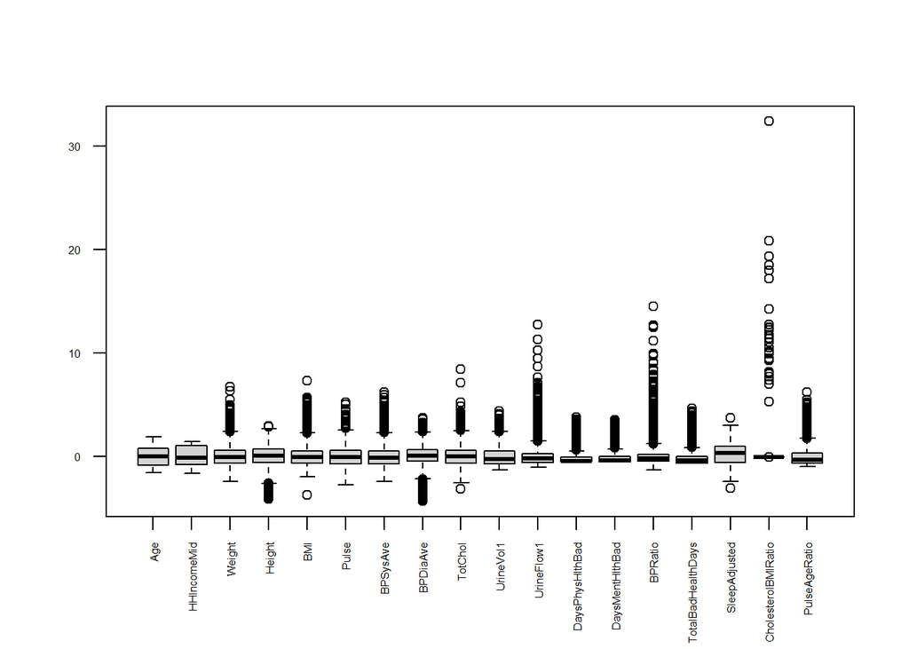

```r
boxplot(numerical_data[, sapply(numerical_data, is.numeric)],las = 2, cex.axis = 0.5)
```

```r
# 1) Identify them
identify_outliers <- function(x) {
  Q1 <- quantile(x, 0.25, na.rm = TRUE)
  Q3 <- quantile(x, 0.75, na.rm = TRUE)
  IQR_value <- Q3 - Q1
  outliers <- x < (Q1 - 1.5 * IQR_value) | x > (Q3 + 1.5 * IQR_value)
  return(outliers)
}

# Apply outlier function to each numeric column
outlier_matrix <- sapply(numerical_data[, sapply(numerical_data, is.numeric)], identify_outliers)

# Check which columns and rows have outliers
outliers_by_variable <- colSums(outlier_matrix) # Number of outliers per variable
outliers_by_variable
```

```
##                 Age         HHIncomeMid              Weight              Height
##                   0                   0                 109                  88
##                 BMI               Pulse            BPSysAve            BPDiaAve
##                 177                  51                 155                 175
##             TotChol           UrineVol1          UrineFlow1     DaysPhysHlthBad
##                  97                 174                 374                 626
##     DaysMentHlthBad             BPRatio  TotalBadHealthDays       SleepAdjusted
##                 736                 311                 754                  24
## CholesterolBMIRatio       PulseAgeRatio
##                 108                 395
```

From that we can see that we have many outliers in the columns DaysPhysHlthBad, DaysMentHlthBad, and TotalBadHealthDays. From this we can judge that they have high uniqueness relative to the rest of the variables, which can mess with our models, so it would be best to remove these columns and do the unsupervised learning on the rest of the variables.

```r
numerical_data = numerical_data %>% dplyr::select(-DaysPhysHlthBad, -DaysMentHlthBad,
                                           -TotalBadHealthDays)
```

Before removing the outliers, we can check the correlation matrix to see if we can remove some columns that don’t show any strong relationships or some that have only one strong relation.

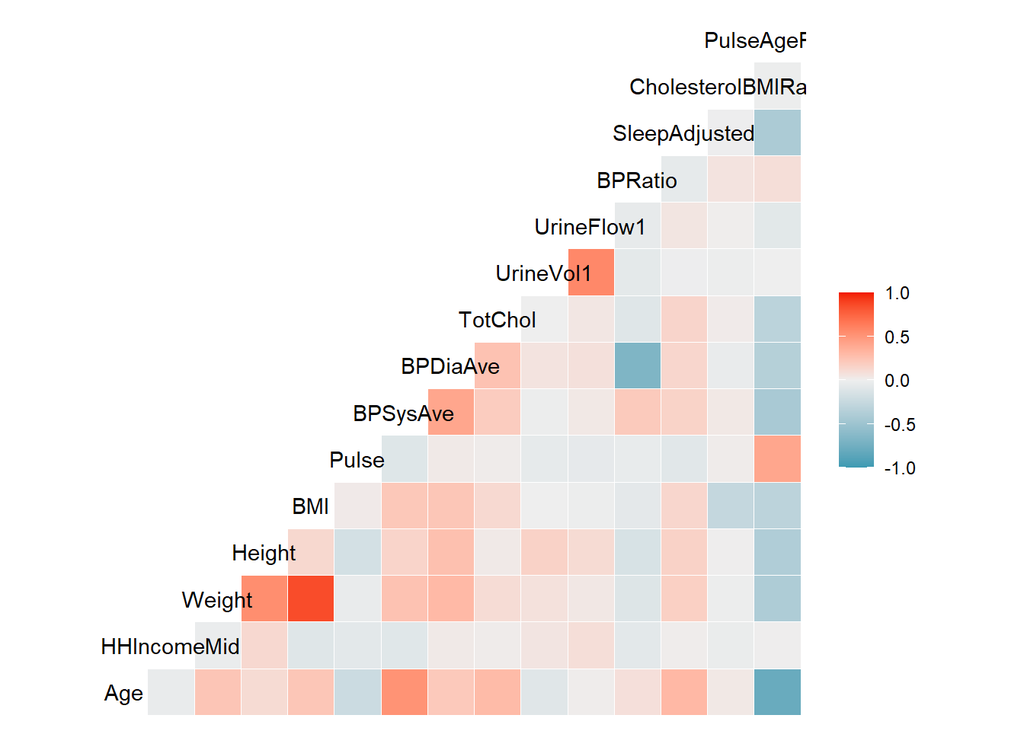

```r
ggcorr(numerical_data)
```

From this we can see that CholestrolBMIRatio only has weak relations, UrineVol1 and UrineFlow1 are strongly corelated, so we can remove one of them (remove UrineFlow1 as it has more outliers). We decided to keep both BMI and Weight for now.

```r
numerical_data = numerical_data %>% dplyr::select(-CholesterolBMIRatio, -UrineFlow1)
```

2. Remove rows with outliers

```r
# new outlier matrix
outlier_matrix <- sapply(numerical_data[, sapply(numerical_data, is.numeric)], identify_outliers)
cleaned_data <- numerical_data[!rowSums(outlier_matrix), ]
```

Checking the standard deviation

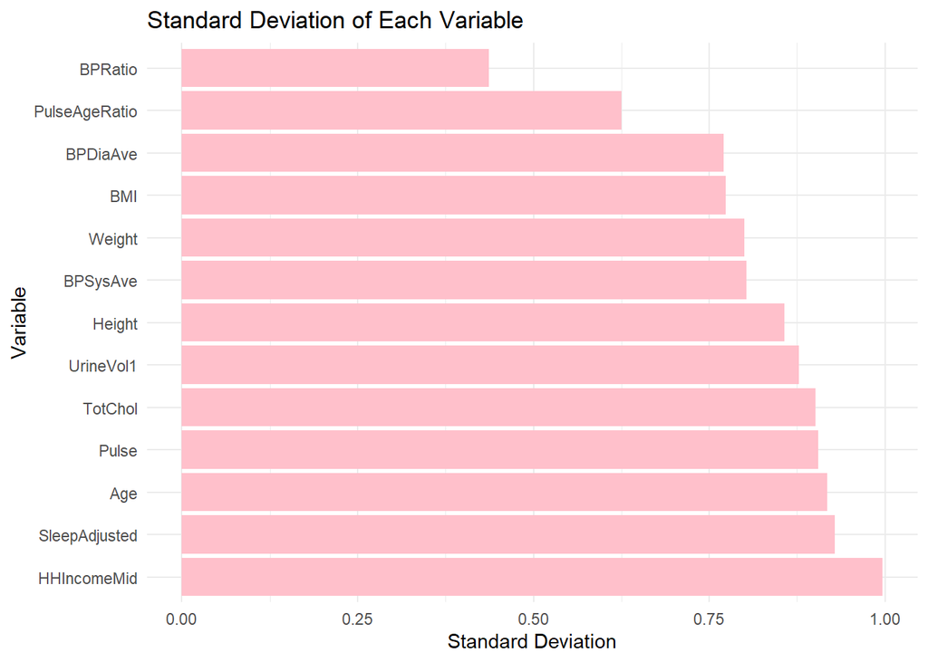

```r
sd_values = sapply(cleaned_data[, sapply(cleaned_data, is.numeric)], sd, na.rm = TRUE)
sd_df <- data.frame(Variable = names(sd_values), SD = sd_values)
ggplot(sd_df, aes(x = reorder(Variable, -SD), y = SD)) +
  geom_bar(stat = "identity", fill = "pink") +
  coord_flip() +  # Flip the chart for easier readability
  theme_minimal() +
  labs(title = "Standard Deviation of Each Variable", x = "Variable", y = "Standard Deviation")
```

From this we can see that BPRatio has a relatively smaller standard deviation, which can mean that it does not contribute much to the variability of the data. Hence, we can remove it.

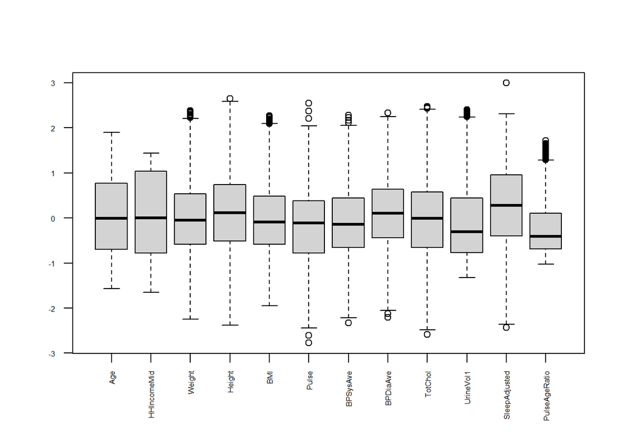

```r
numerical_data = numerical_data %>% dplyr::select(-BPRatio)
outlier_matrix <- sapply(numerical_data[, sapply(numerical_data, is.numeric)], identify_outliers)
final_cleaned_data <- numerical_data[!rowSums(outlier_matrix), ]
boxplot(final_cleaned_data[, sapply(final_cleaned_data, is.numeric)],las = 2, cex.axis = 0.5)
```

# Visualization

1. Create histograms to show the distribution of each variable.

This allows us to see which variables are normally distributed, which are skewed, which are multimodal(have peaks in the histogram), or which have low variance.

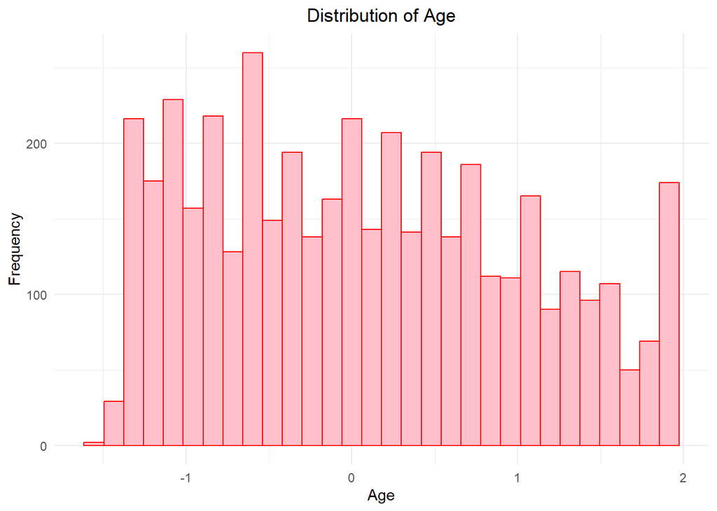

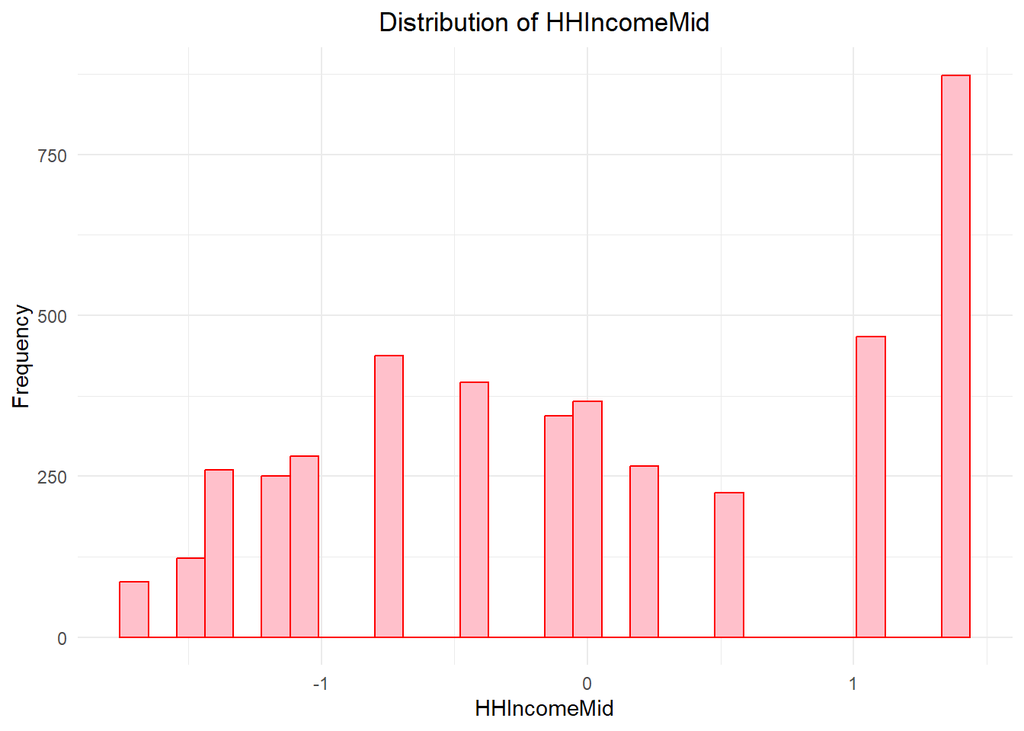

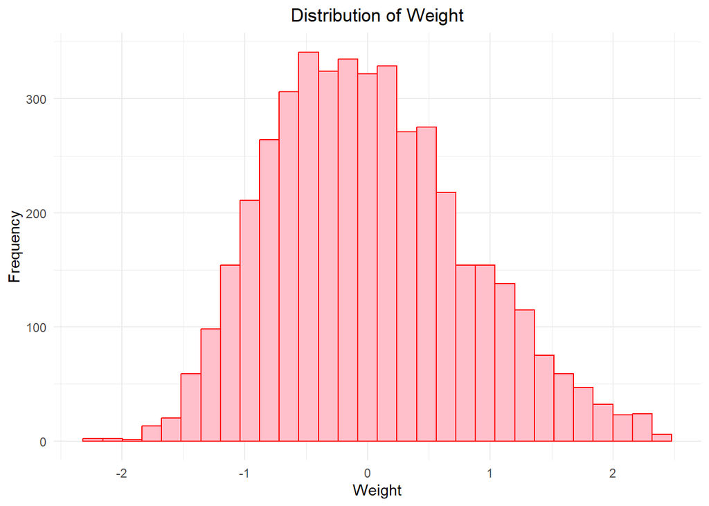

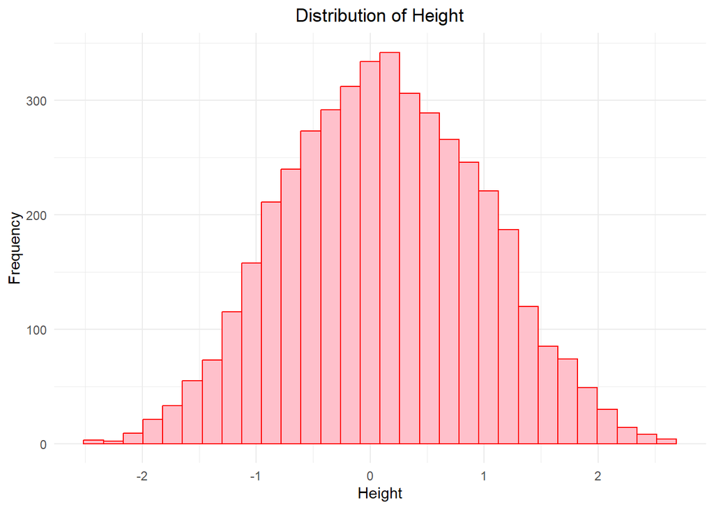

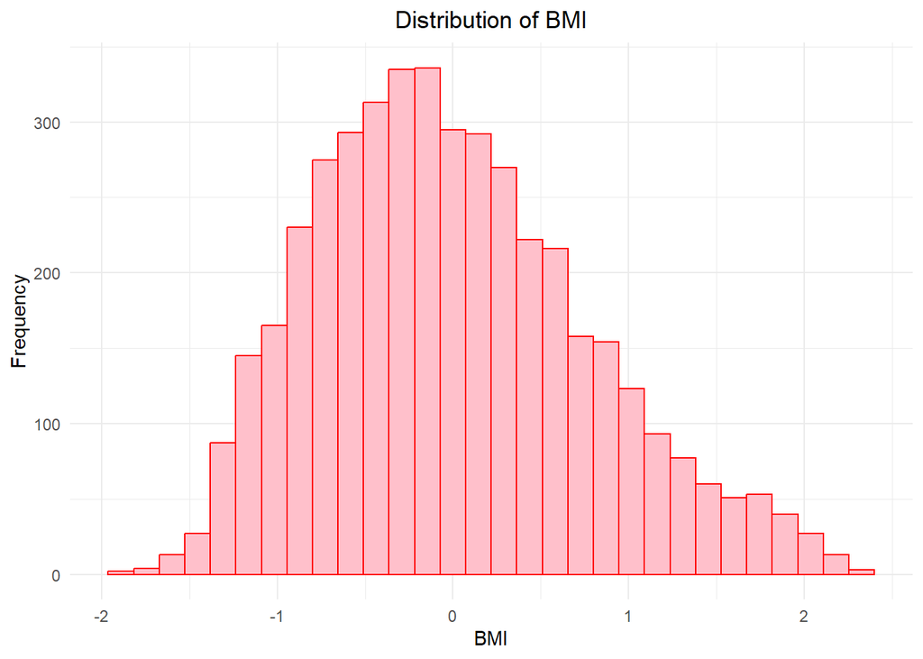

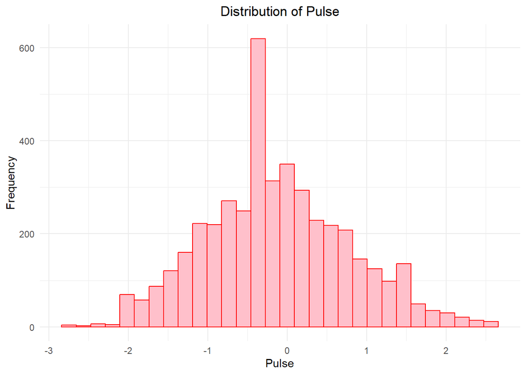

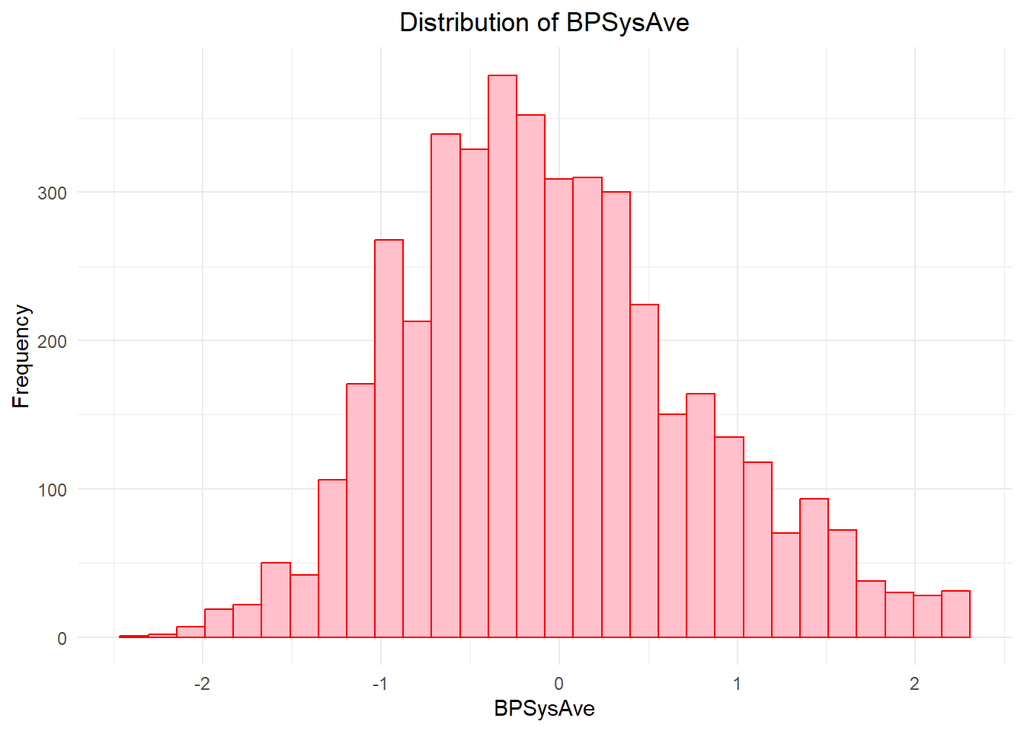

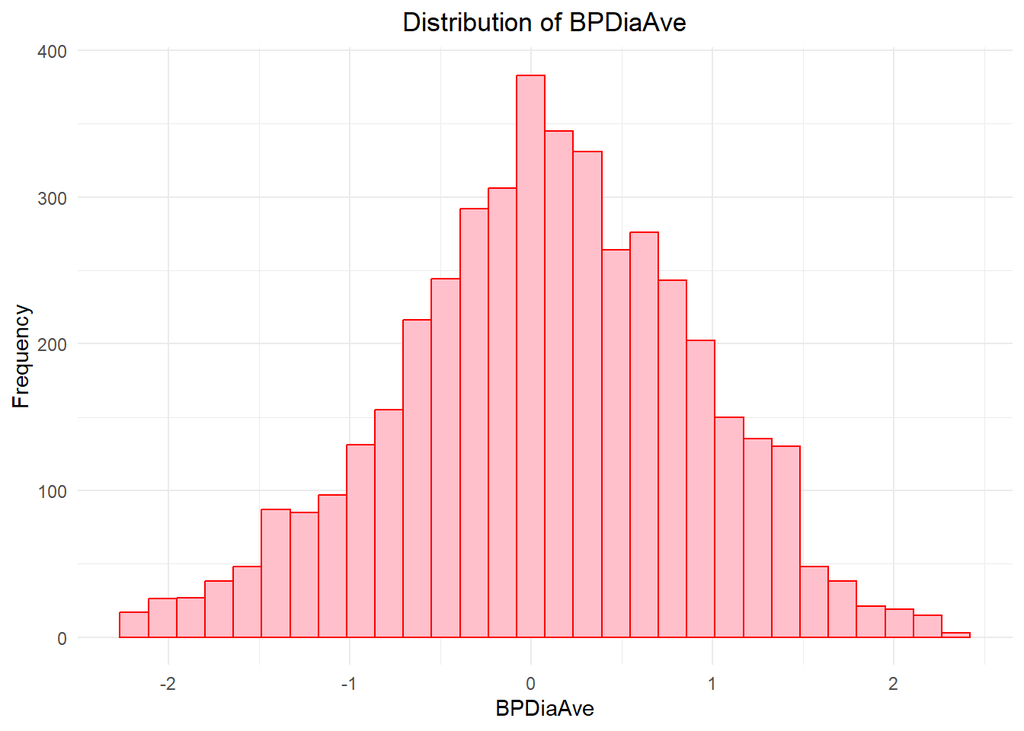

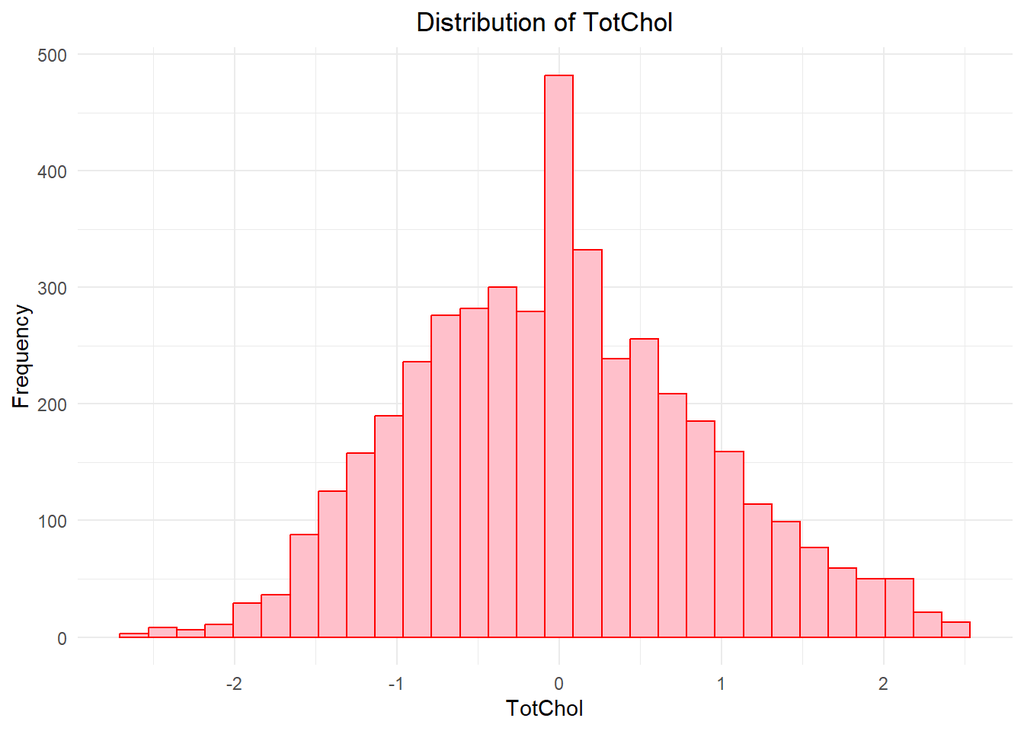

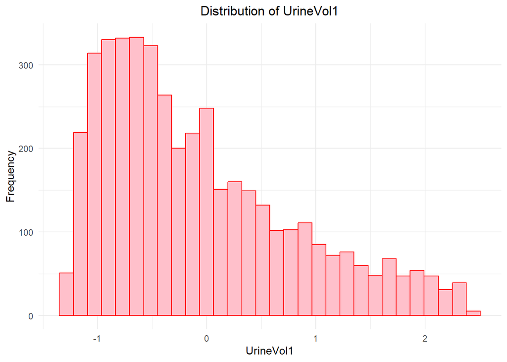

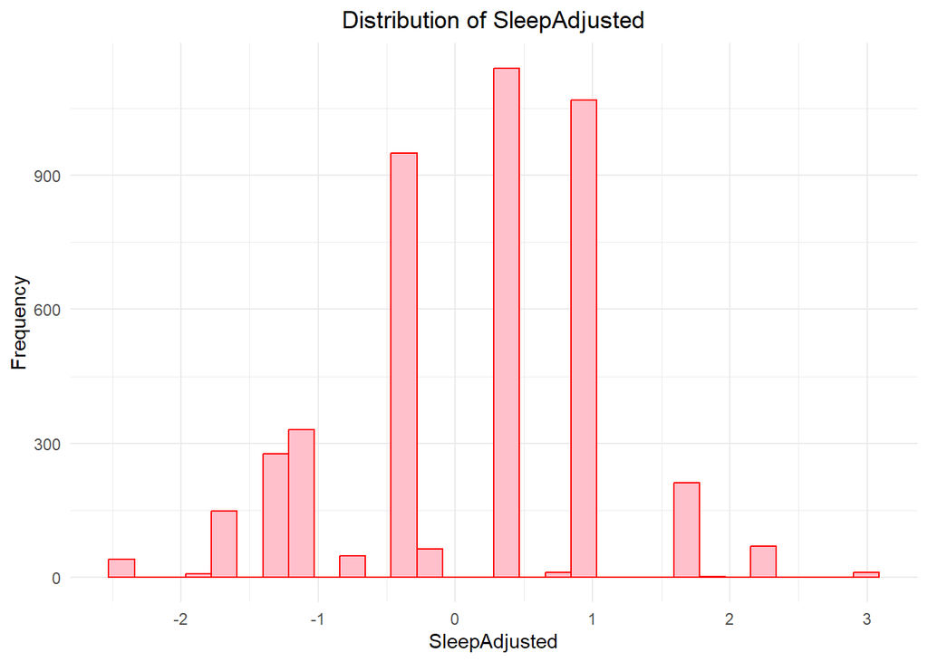

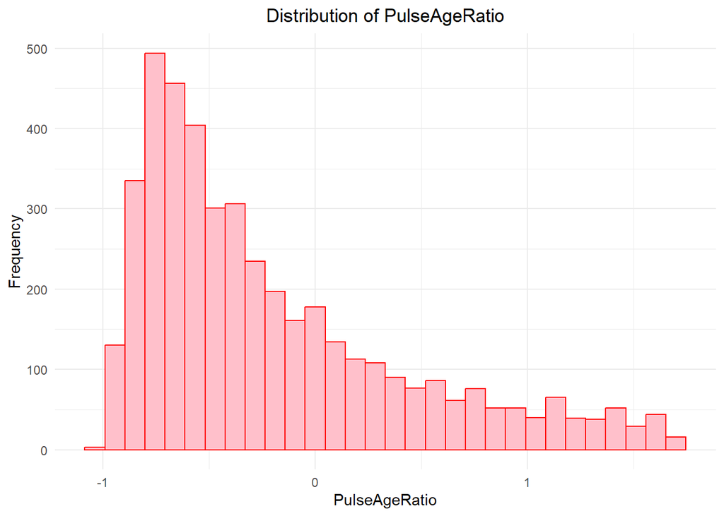

```r
numeric_vars <- c("Age", "HHIncomeMid", "Weight", "Height", "BMI", "Pulse", "BPSysAve",
                  "BPDiaAve", "TotChol", "UrineVol1", "SleepAdjusted", "PulseAgeRatio")
for (var in numeric_vars) {
  p <- ggplot(final_cleaned_data, aes_string(var)) +
    geom_histogram(bins = 30, fill = "pink", color = "red") +
    theme_minimal() +
    ggtitle(paste("Distribution of", var)) +
    xlab(var) + ylab("Frequency") +
    theme(plot.title = element_text(hjust = 0.5))

  print(p)
}
```

If we were to use UrineVol1 or PulseAgeRatio for clustering, we will need to transform them as they are skewed. SleepAdjusted has some peaks, which suggest that it already has some natural clusters.

# Deal with skewness.

Only UrineVol1 and PulseAgeRatio really exhibits heavy skewness.

```r
# for UrineVol1
offset <- abs(min(final_cleaned_data$UrineVol1)) + 1
boxcox_result <- boxcox((final_cleaned_data$UrineVol1 + offset) ~ 1)
```

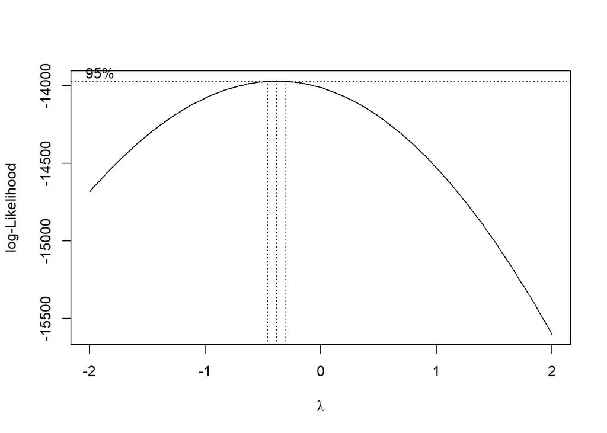

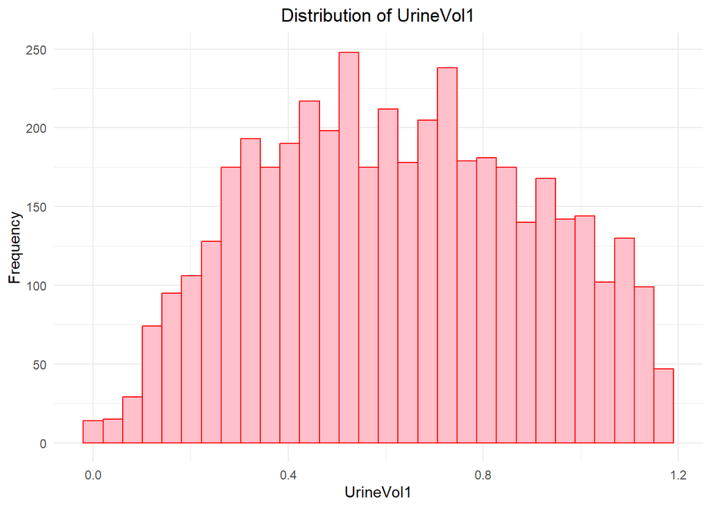

```r
lambda <- boxcox_result$x[which.max(boxcox_result$y)]
final_cleaned_data$UrineVol1 <- ((final_cleaned_data$UrineVol1 + offset)^lambda - 1) / lambda

p <- ggplot(final_cleaned_data, aes_string("UrineVol1")) +
    geom_histogram(bins = 30, fill = "pink", color = "red") +
    theme_minimal() +
    ggtitle(paste("Distribution of", "UrineVol1")) +
    xlab("UrineVol1") + ylab("Frequency") +
    theme(plot.title = element_text(hjust = 0.5))

print(p)
```

```r
#for PulseAgeRatio
offset <- abs(min(final_cleaned_data$PulseAgeRatio)) + 1
boxcox_result <- boxcox((final_cleaned_data$PulseAgeRatio + offset) ~ 1)
```

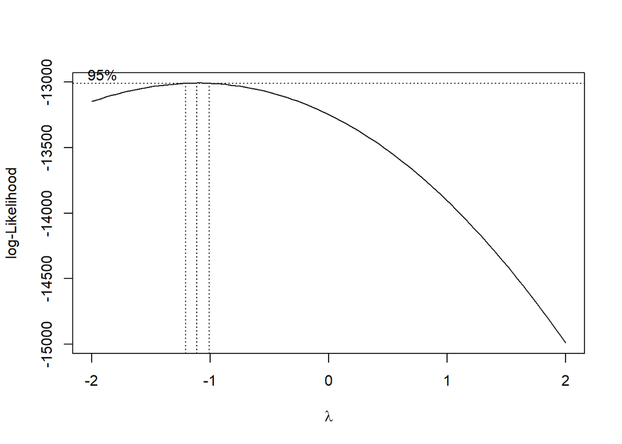

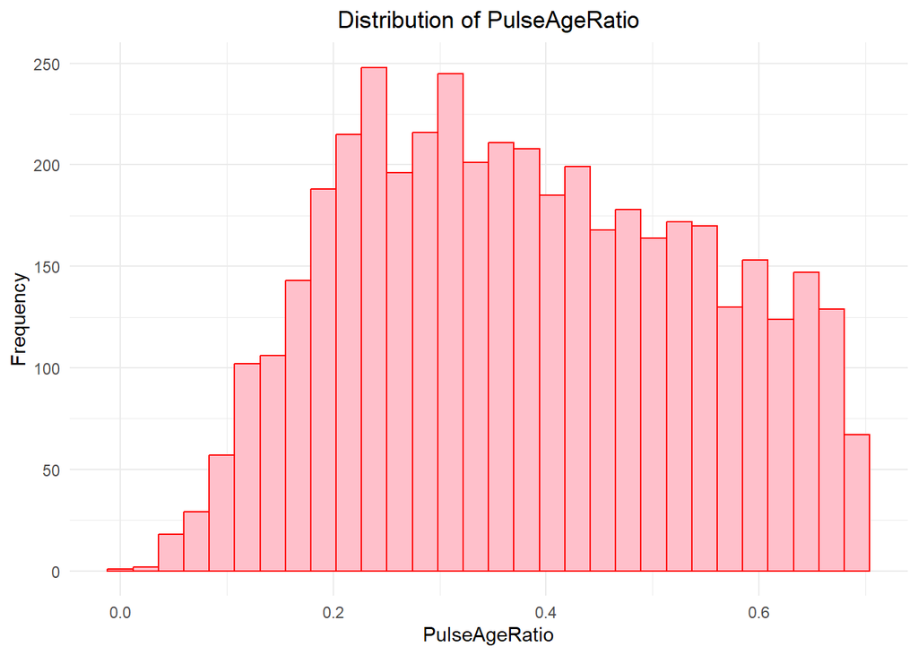

```r
lambda <- boxcox_result$x[which.max(boxcox_result$y)]
final_cleaned_data$PulseAgeRatio <- ((final_cleaned_data$PulseAgeRatio + offset)^lambda - 1) / lambda

p <- ggplot(final_cleaned_data, aes_string("PulseAgeRatio")) +
    geom_histogram(bins = 30, fill = "pink", color = "red") +
    theme_minimal() +
    ggtitle(paste("Distribution of", "PulseAgeRatio")) +
    xlab("PulseAgeRatio") + ylab("Frequency") +
    theme(plot.title = element_text(hjust = 0.5))

print(p)
```

# Correlation

Correlation of the numerical data we have decided to keep:

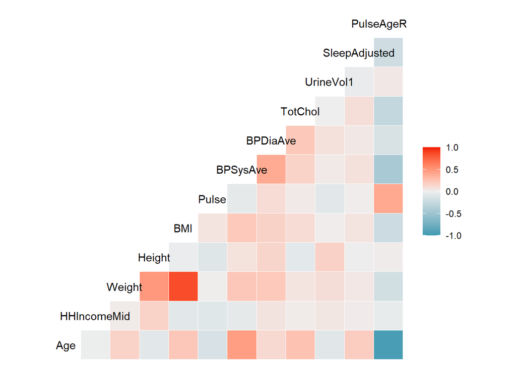

```r
ggcorr(final_cleaned_data)
```

# PCA

```r
pca = prcomp(final_cleaned_data, scale=T)
summary(pca)
```

```
## Importance of components:
##                           PC1    PC2    PC3     PC4     PC5     PC6     PC7
## Standard deviation     1.7008 1.3529 1.1627 1.09528 1.00535 0.95920 0.94189
## Proportion of Variance 0.2411 0.1525 0.1126 0.09997 0.08423 0.07667 0.07393
## Cumulative Proportion  0.2411 0.3936 0.5062 0.60621 0.69044 0.76711 0.84104
##                            PC8     PC9    PC10    PC11    PC12
## Standard deviation     0.86612 0.81172 0.69350 0.11158 0.07129
## Proportion of Variance 0.06251 0.05491 0.04008 0.00104 0.00042
## Cumulative Proportion  0.90355 0.95846 0.99854 0.99958 1.00000
```

We can observe that with 7 variables we are able to explain 84.1% of the data.

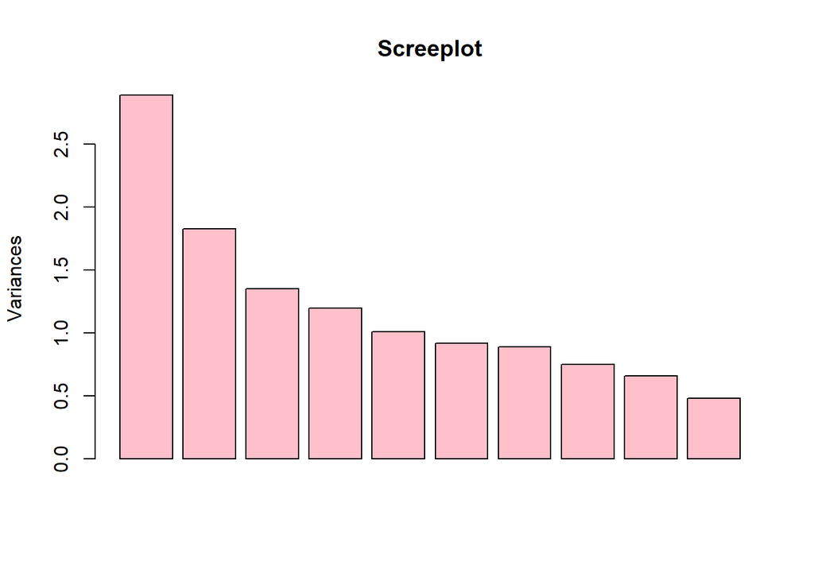

```r
screeplot(pca,main="Screeplot",col="pink",type="barplot",pch=19) #Variable importance
```

A nicer view than screeplot is Elbow Method (factoextra)

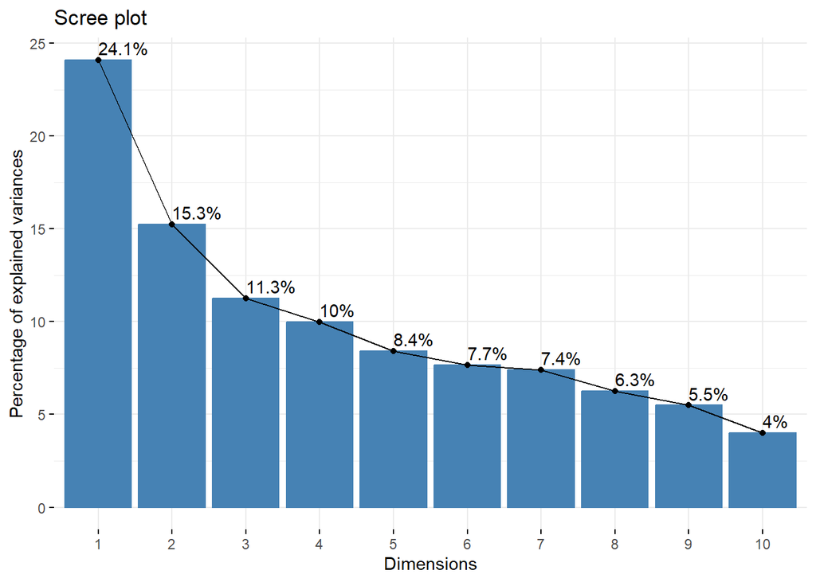

```r
fviz_screeplot(pca, addlabels = TRUE)
```

We can reaffirm with this graph that PCA can be developed correctly with 7 variables

Let us go component by component

First component:

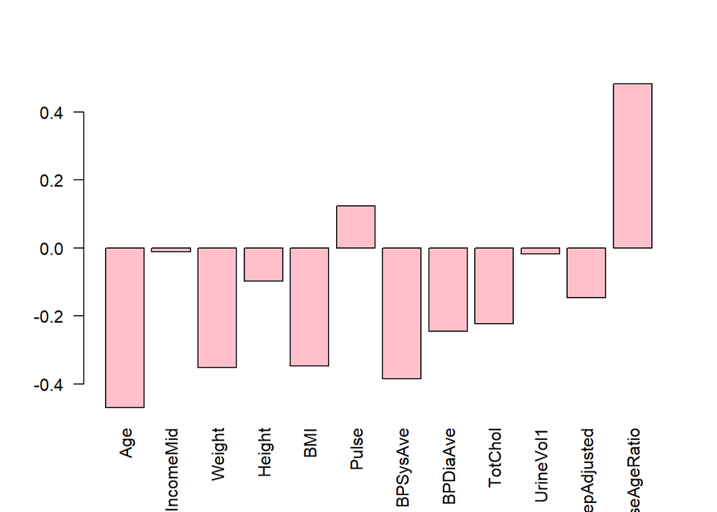

```r
barplot(pca$rotation[,1], las=2, col="pink")
```

```r
# This barplot shows all the values in the first column (var 1) of the vector matrix

sum(pca$rotation[,1]^2) #This sum should always be equal to 1
```

```
## [1] 1
```

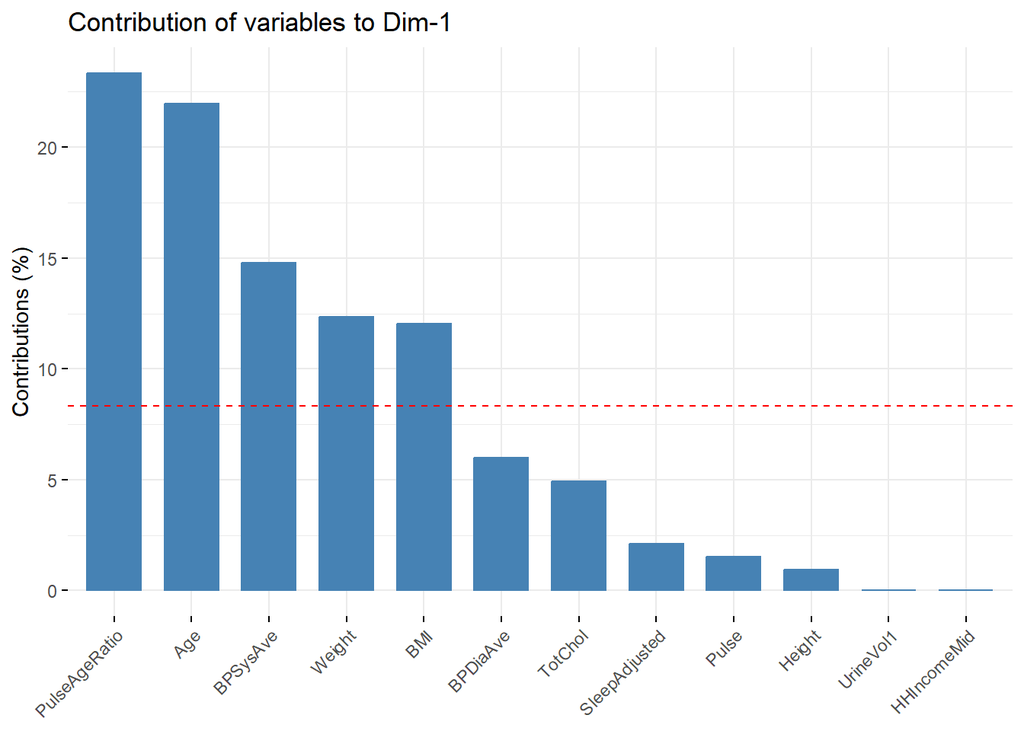

```r
fviz_contrib(pca, choice = "var", axes = 1)
```

We can observe that the most relevant variables for the first component are: PulseAgeRatio, Age, BPSysAve, Weight and BMI

The first component appears to represent a general health index, particularly cardiovascular health and factors related to age and body weight.

Top 10 people in general health index:

```r
# use the data before normalization to get the real values
normal_cleaned_data = new_data %>% dplyr::select(-DaysPhysHlthBad, -DaysMentHlthBad,
                                      -TotalBadHealthDays, -CholesterolBMIRatio,
                                      -UrineFlow1, -BPRatio)
normal_cleaned_data <- normal_cleaned_data[!rowSums(outlier_matrix), ]

# Get the indices of the top 10 observations along the first principal component
top_indices1 <- order(pca$x[,1], decreasing = TRUE)[1:10]

# Use these indices to subset the original dataset and view the variable information
top_observations1 <- normal_cleaned_data[top_indices1, ]

# Display the top observations
print(top_observations1)
```

```
## # A tibble: 10 × 13
##    Gender   Age HHIncomeMid Weight Height   BMI Pulse BPSysAve BPDiaAve TotChol
##    <fct>  <int>       <dbl>  <dbl>  <dbl> <dbl> <int>    <int>    <int>   <dbl>
##  1 male      13      100000   29.1   148.  13.3    72       94       40    4.55
##  2 male      11       30000   31.8   143.  15.6    62       97       41    3.47
##  3 female     9       87500   28.7   140.  14.8    54       93       47    4.53
##  4 female    16       40000   49.1   155.  20.5    92       96       39    3.98
##  5 female    10       87500   26.6   140   13.6    58      103       59    4.5
##  6 female    13       40000   39.4   149.  17.7    76       90       53    4.87
##  7 male      15      100000   42.6   171.  14.6    82       87       61    3.98
##  8 male      11       40000   38.2   147.  17.6    64      103       50    3.8
##  9 male      12      100000   39.6   155.  16.4    66       90       64    3.8
## 10 female    14       22500   45.3   150.  20      80       92       60    3.47
## # ℹ 3 more variables: UrineVol1 <int>, SleepAdjusted <dbl>, PulseAgeRatio <dbl>
```

Second component:

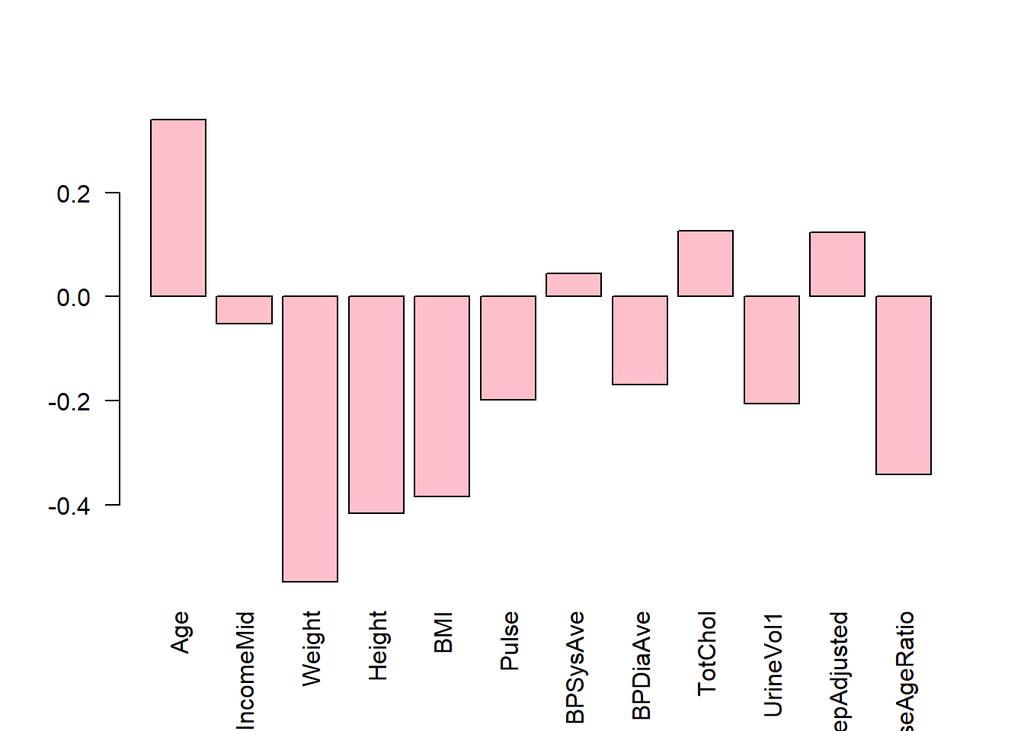

```r
barplot(pca$rotation[,2], las=2, col="pink")
```

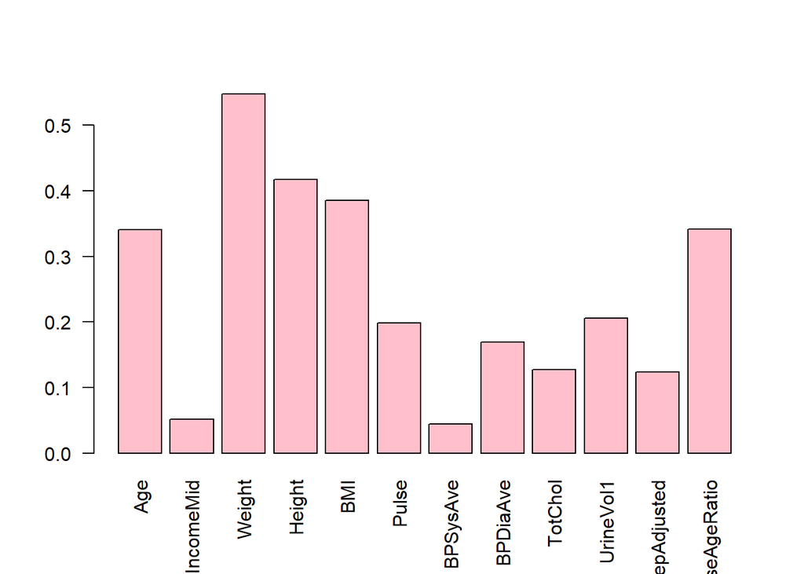

```r
barplot(abs(pca$rotation[,2]), las=2, col="pink")
```

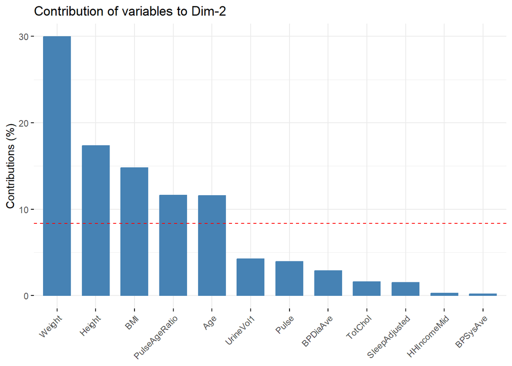

```r
fviz_contrib(pca, choice = "var", axes = 2)
```

We can observe that the most relevant variables for the second component are: Weight, Height, BMI, Age and PulseAgeRatio

The second component seems to capture a body composition index, focusing on characteristics that define physical development, body size, and possibly the influence of age on these metrics.

Third component:

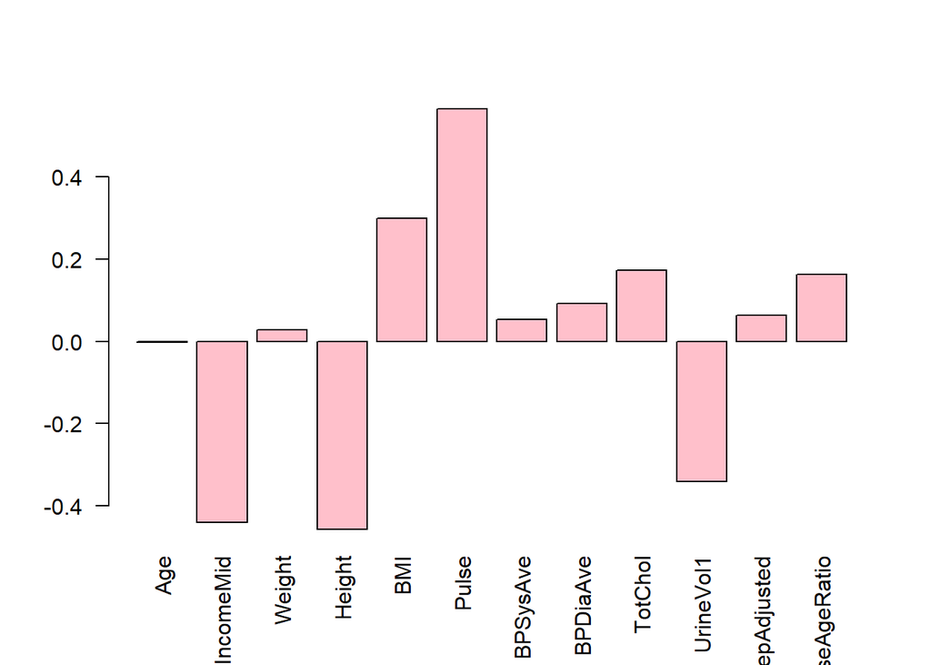

```r
barplot(pca$rotation[,3], las=2, col="pink")
```

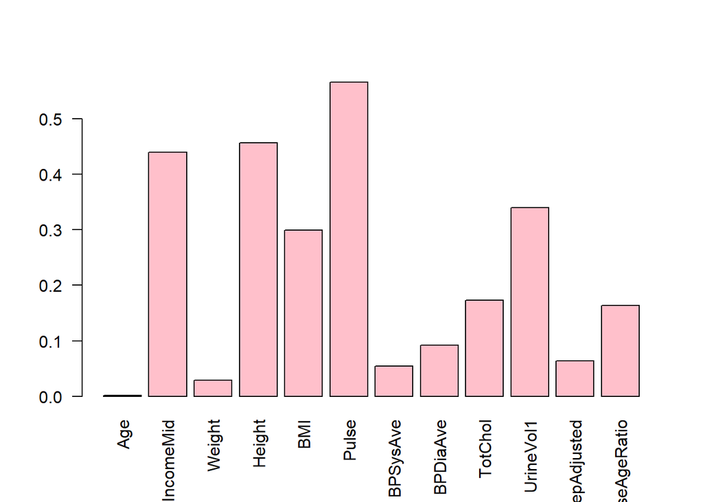

```r
barplot(abs(pca$rotation[,3]), las=2, col="pink")
```

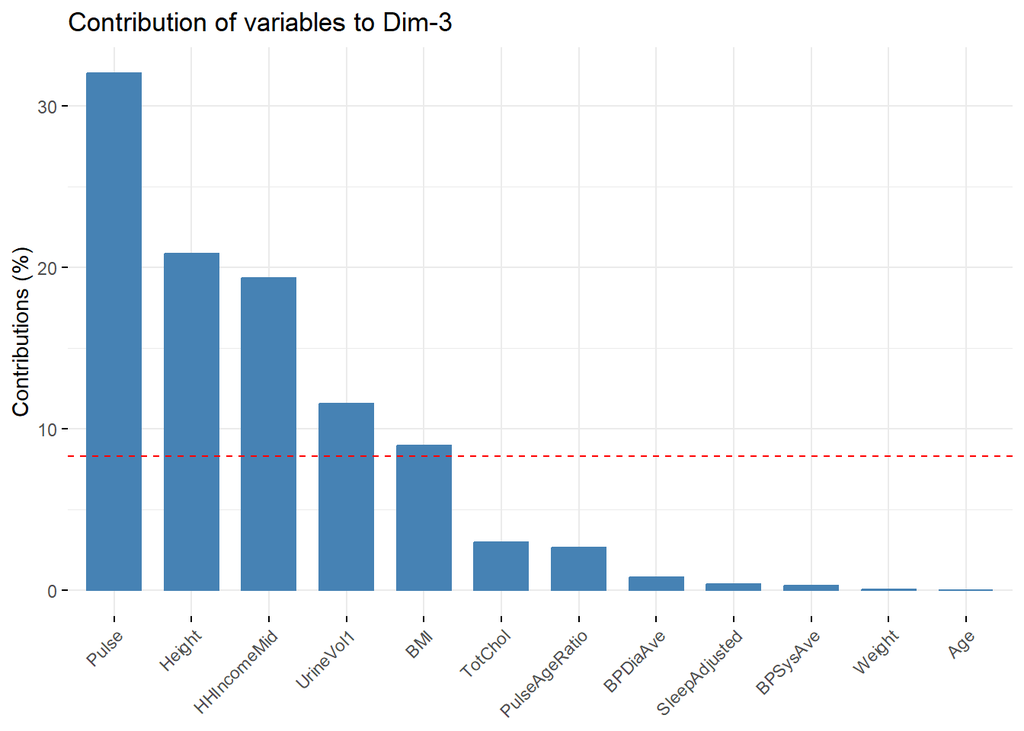

```r
fviz_contrib(pca, choice = "var", axes = 3)
```

We can observe that the most relevant variables for the third component are: Pulse, HHIncomeMide, Height, BMI and UrineVol1

The third component seems to represent a socioeconomic and physiological health index.